# Unsupervised learning - clustering and dimension reduction

```r
#2nd iteration
#average centroid:
a <- summarise(cluster0, mean_sepallength = mean(Sepal.Length))
b <- summarise(cluster0, mean_sepalwidth = mean(Sepal.Width))
c <- summarise(cluster0, mean_sepallength = mean(Petal.Length))
d <- summarise(cluster0, mean_sepalwidth = mean(Petal.Width))

averageCluster0 <- c(a,b,c,d)
# averageCluster0

e <- summarise(cluster1, mean_sepallength = mean(Sepal.Length))
f <- summarise(cluster1, mean_sepalwidth = mean(Sepal.Width))
g <- summarise(cluster1, mean_sepallength = mean(Petal.Length))
h <- summarise(cluster1, mean_sepalwidth = mean(Petal.Width))

averageCluster1 <- c(e,f,g,h)
# averageCluster1

#get distance of each flower to average centroid
for(i in 1:nrow(cluster0)) {
  cluster0[i,6:9] <- cluster0[i,1:4] - averageCluster0
  cluster0[i,6:9] <- (cluster0[i,6:9] ^ 2)
  cluster0[i,10:13] <- cluster0[i,1:4] - averageCluster1
  cluster0[i,10:13] <- (cluster0[i,10:13] ^ 2)
}
cluster0 <- transform(cluster0, sum0=rowSums(cluster0[,6:9]))
cluster0 <- transform(cluster0, sum1=rowSums(cluster0[,10:13]))
# cluster0

for(i in 1:nrow(cluster1)) {
  cluster1[i,6:9] <- cluster1[i,1:4] - averageCluster0
  cluster1[i,6:9] <- (cluster1[i,6:9] ^ 2)
  cluster1[i,10:13] <- cluster1[i,1:4] - averageCluster1
  cluster1[i,10:13] <- (cluster1[i,10:13] ^ 2)
}
cluster1 <- transform(cluster1, sum0=rowSums(cluster1[,6:9]))
cluster1 <- transform(cluster1, sum1=rowSums(cluster1[,10:13]))
# cluster1

#re-cluster
for(i in 1:nrow(cluster0)) {
  if (cluster0[i,14] < cluster0[i,15]){
    cluster0[i,5] = 0
  }else{
    cluster0[i,5] = 1
  }
}
# cluster0
for(i in 1:nrow(cluster1)) {
  if (cluster1[i,14] < cluster1[i,15]){
    cluster1[i,5] = 0
  }else{
    cluster1[i,5] = 1
  }
}
# cluster1

#combining singular clusters back to 1 dataframe
fullIris <- rbind(cluster0, cluster1)
# fullIris

#split into 2 vectors
cluster0 <- filter(fullIris, Cluster == 0)
cluster0
```

| Sepal.Length | Sepal.Width | Petal.Length | Petal.Width | Cluster | Sepal.Length.1 | Sepal.Width.1 | Petal.Length.1 | Petal.Width.1 | Sepal.Length.2 | Sepal.Width.2 | Petal.Length.2 | Petal.Width.2 | sum0 | sum1 |
| --- | --- | --- | --- | --- | --- | --- | --- | --- | --- | --- | --- | --- | --- | --- |
| 6.9 | 3.1 | 4.9 | 1.5 | 0 | 0.316255058 | 3.829807e-02 | 0.0139900567 | 0.0495421436 | 3.47135734 | 4.285626e-02 | 10.228775 | 1.3326070 | 0.41808533 | 15.075596 |
| 5.7 | 2.8 | 4.5 | 1.3 | 0 | 0.406577639 | 1.087871e-02 | 0.2686137126 | 0.1785744017 | 0.43977839 | 2.570668e-01 | 7.830179 | 0.9108526 | 0.86464447 | 9.437876 |
| 6.3 | 3.3 | 4.7 | 1.6 | 0 | 0.001416349 | 1.565776e-01 | 0.1013018846 | 0.0150260146 | 1.59556787 | 4.924592e-05 | 8.989477 | 1.5734841 | 0.27432189 | 12.158578 |
| 6.6 | 2.9 | 4.6 | 1.3 | 0 | 0.068835704 | 1.849925e-05 | 0.1749577986 | 0.1785744017 | 2.44346260 | 1.656633e-01 | 8.399828 | 0.9108526 | 0.42238640 | 11.919806 |
| 5.2 | 2.7 | 3.9 | 1.4 | 0 | 1.294212048 | 4.173893e-02 | 1.2505491964 | 0.1040582726 | 0.02662050 | 3.684703e-01 | 4.832284 | 1.1117298 | 2.69055845 | 6.339104 |
| 5.9 | 3.0 | 4.2 | 1.5 | 0 | 0.191523876 | 9.158284e-03 | 0.6695814545 | 0.0495421436 | 0.74504155 | 9.425977e-02 | 6.241231 | 1.3326070 | 0.91980576 | 8.413139 |
| 6.0 | 2.2 | 4.0 | 1.0 | 0 | 0.113996994 | 4.960400e-01 | 1.0368932825 | 0.5221227888 | 0.92767313 | 1.225488e+00 | 5.281933 | 0.4282210 | 2.16905307 | 7.863315 |
| 6.1 | 2.9 | 4.7 | 1.4 | 0 | 0.056470112 | 1.849925e-05 | 0.1013018846 | 0.1040582726 | 1.13030471 | 1.656633e-01 | 8.989477 | 1.1117298 | 0.26184877 | 11.397175 |
| 5.6 | 3.0 | 4.5 | 1.5 | 0 | 0.544104521 | 9.158284e-03 | 0.2686137126 | 0.0495421436 | 0.31714681 | 9.425977e-02 | 7.830179 | 1.3326070 | 0.87141866 | 9.574192 |
| 5.8 | 2.7 | 4.1 | 1.0 | 0 | 0.289050757 | 4.173893e-02 | 0.8432373685 | 0.5221227888 | 0.58240997 | 3.684703e-01 | 5.751582 | 0.4282210 | 1.69614984 | 7.130683 |

[output cut: 86 more lines]

```r
cluster1 <- filter(fullIris, Cluster == 1)
cluster1
```

| Sepal.Length | Sepal.Width | Petal.Length | Petal.Width | Cluster | Sepal.Length.1 | Sepal.Width.1 | Petal.Length.1 | Petal.Width.1 | Sepal.Length.2 | Sepal.Width.2 | Petal.Length.2 | Petal.Width.2 | sum0 | sum1 |
| --- | --- | --- | --- | --- | --- | --- | --- | --- | --- | --- | --- | --- | --- | --- |
| 5.1 | 3.5 | 1.4 | 0.2 | 1 | 1.5317389 | 3.548572e-01 | 13.091947 | 2.3182518 | 0.003988920 | 3.724223e-02 | 9.105571e-02 | 0.021203447 | 17.296795 | 0.15349030 |
| 4.7 | 3.2 | 1.3 | 0.2 | 1 | 2.6818465 | 8.743785e-02 | 13.825603 | 2.3182518 | 0.113462604 | 1.145275e-02 | 1.614066e-01 | 0.021203447 | 18.913139 | 0.30752539 |
| 5.0 | 3.6 | 1.4 | 0.2 | 1 | 1.7892658 | 4.839970e-01 | 13.091947 | 2.3182518 | 0.001357341 | 8.583872e-02 | 9.105571e-02 | 0.021203447 | 17.683462 | 0.19945522 |
| 5.4 | 3.9 | 1.7 | 0.4 | 1 | 0.8791583 | 9.914163e-01 | 11.010979 | 1.7492196 | 0.131883657 | 3.516282e-01 | 3.077870e-06 | 0.002957833 | 14.630773 | 0.48647276 |
| 4.8 | 3.4 | 1.6 | 0.2 | 1 | 2.3643196 | 2.457174e-01 | 11.684635 | 2.3182518 | 0.056094183 | 8.645737e-03 | 1.035396e-02 | 0.021203447 | 16.612924 | 0.09629732 |
| 5.1 | 3.7 | 1.5 | 0.4 | 1 | 1.5317389 | 6.331368e-01 | 12.378291 | 1.7492196 | 0.003988920 | 1.544352e-01 | 4.070483e-02 | 0.002957833 | 16.292386 | 0.20208680 |
| 5.1 | 3.3 | 1.7 | 0.5 | 1 | 1.5317389 | 1.565776e-01 | 11.010979 | 1.4947034 | 0.003988920 | 4.924592e-05 | 3.077870e-06 | 0.023835026 | 14.193999 | 0.02787627 |
| 4.8 | 3.4 | 1.9 | 0.2 | 1 | 2.3643196 | 2.457174e-01 | 9.723667 | 2.3182518 | 0.056094183 | 8.645737e-03 | 3.930132e-02 | 0.021203447 | 14.651956 | 0.12524469 |
| 5.0 | 3.4 | 1.6 | 0.4 | 1 | 1.7892658 | 2.457174e-01 | 11.684635 | 1.7492196 | 0.001357341 | 8.645737e-03 | 1.035396e-02 | 0.002957833 | 15.468838 | 0.02331487 |
| 4.7 | 3.2 | 1.6 | 0.2 | 1 | 2.6818465 | 8.743785e-02 | 11.684635 | 2.3182518 | 0.113462604 | 1.145275e-02 | 1.035396e-02 | 0.021203447 | 16.772171 | 0.15647276 |

[output cut: 44 more lines]

2. Run PCA on the Iris dataset. Plot a scatter plot of PC1 vs PC2 and include the percent variance those PCs describe.

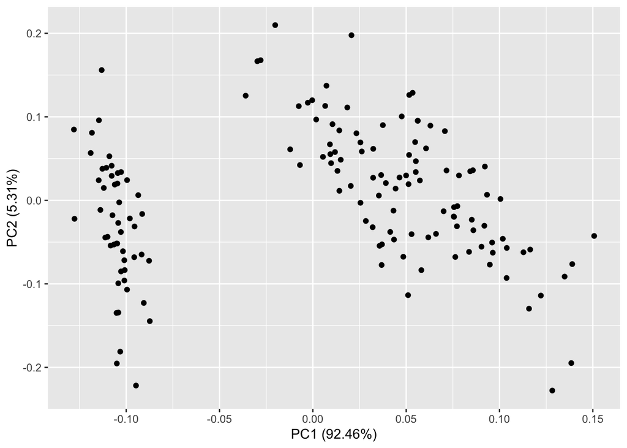

```r
help("prcomp")
iris_pca <- data.matrix(subsetIris)
autoplot(prcomp(iris_pca))
```

3. Run ICA on the Iris dataset. Plot the independent components as a heatmap.

```r
help("fastICA")
a <- fastICA(subsetIris, 4, alg.typ = "parallel", fun = "logcosh", alpha = 1,
             method = "R", row.norm = FALSE, maxit = 200,
             tol = 0.0001, verbose = TRUE)
```

```
## Centering
```

```
## Whitening
```

```
## Symmetric FastICA using logcosh approx. to neg-entropy function
```

```
## Iteration 1 tol = 0.5786252
```

```
## Iteration 2 tol = 0.6115851
```

```
## Iteration 3 tol = 0.1915218
```

```
## Iteration 4 tol = 0.0127545
```

```
## Iteration 5 tol = 0.006185668
```

```
## Iteration 6 tol = 0.003071977
```

```
## Iteration 7 tol = 0.003199441
```

```
## Iteration 8 tol = 0.00290153
```

```
## Iteration 9 tol = 0.003287147
```

```
## Iteration 10 tol = 0.004461442
```

```
## Iteration 11 tol = 0.003072678
```

```
## Iteration 12 tol = 0.00192363
```

```
## Iteration 13 tol = 0.0006588315
```

```
## Iteration 14 tol = 0.0001654505
```

```
## Iteration 15 tol = 9.341521e-05
```

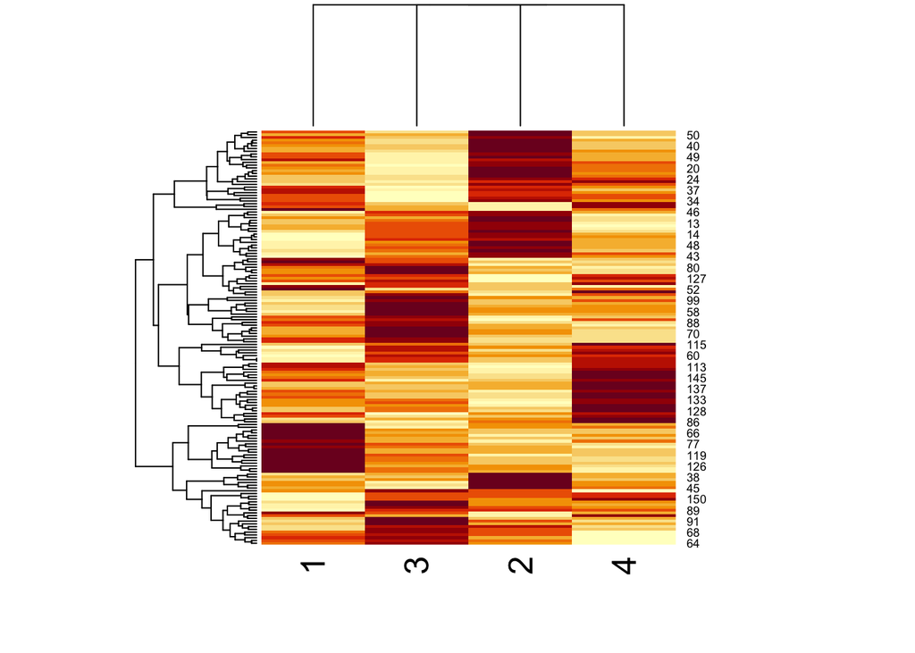

```r
heatmap(a$S)
```

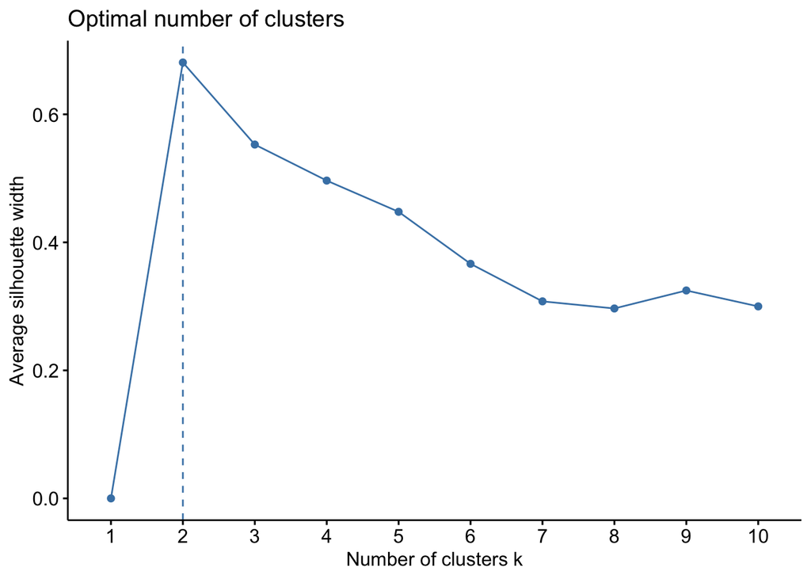

```r
fviz_nbclust(subsetIris, kmeans, method = "silhouette")
```

```r
kIris <- kmeans(subsetIris, 2)
# kIris
# kiris_pca <- data.matrix(kIris)
```

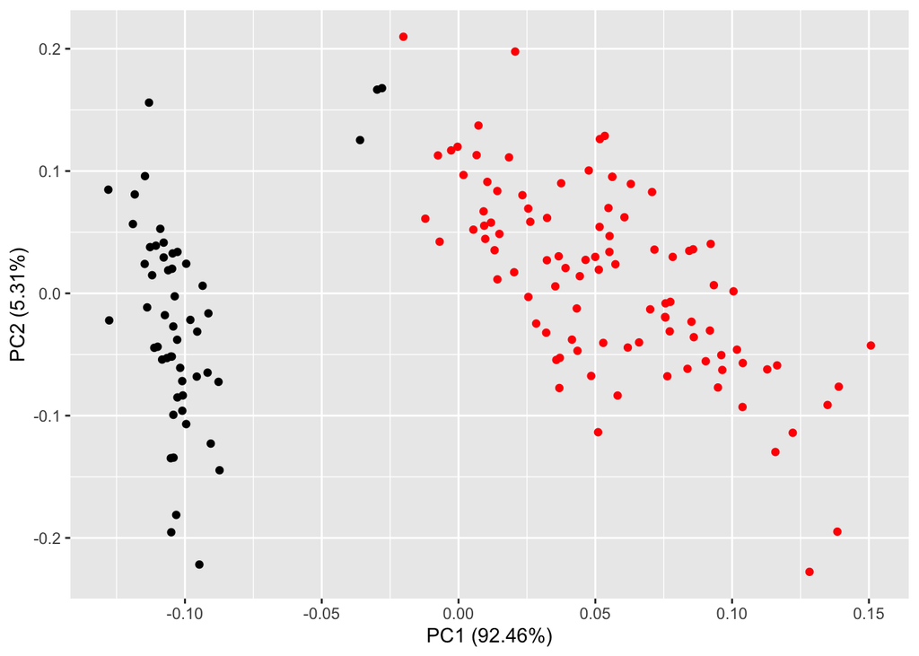

```r
autoplot(prcomp(iris_pca), col=kIris$cluster)
```

5. Use hierarchical clustering to cluster the Iris data.
- Try two different linkage types, and two different distance metrics. (euclidean/manhattan)
- For one linkage type and one distance metric, try two different cut points.
- Using this clustering, color the PCA plot according to the clusters. (6 plots in total)
- 6 clusters
- cut point by cut or height
- color PCA by making column for cut point clusters

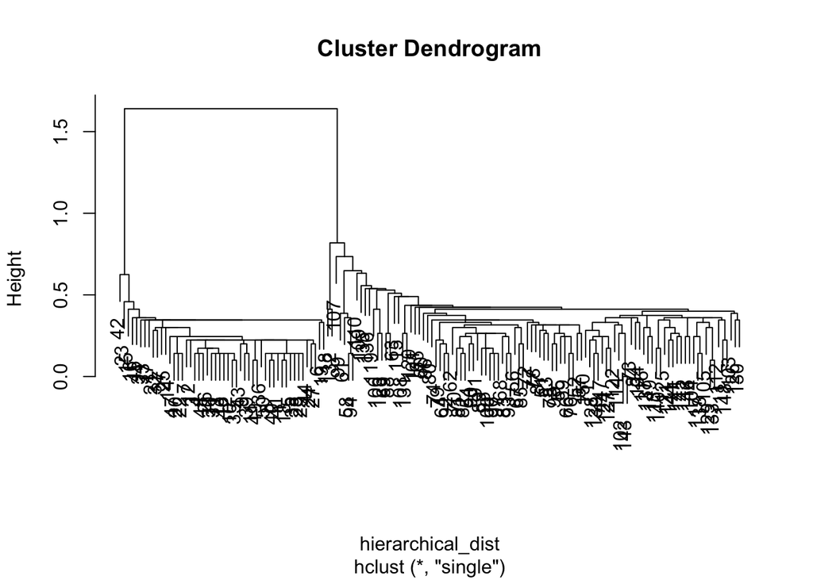

```r
#two different linkage
#single
hierarchical_dist <- dist(subsetIris, method = "euclidean")
tree <- hclust(hierarchical_dist, method="single")
plot(tree)
```

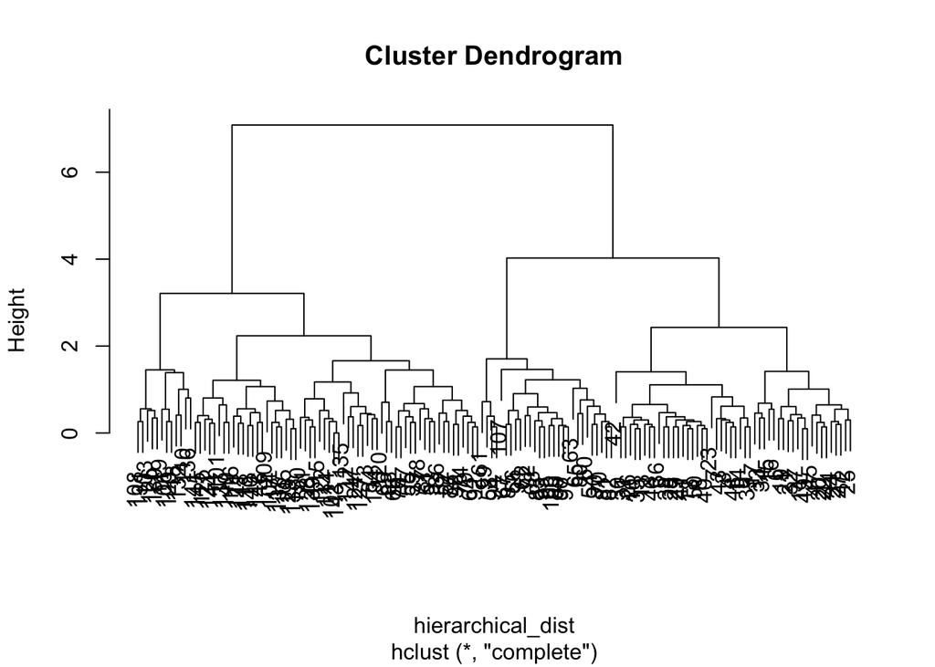

```r
#complete
hierarchical_dist <- dist(subsetIris, method = "euclidean")
tree <- hclust(hierarchical_dist, method="complete")
plot(tree)
```

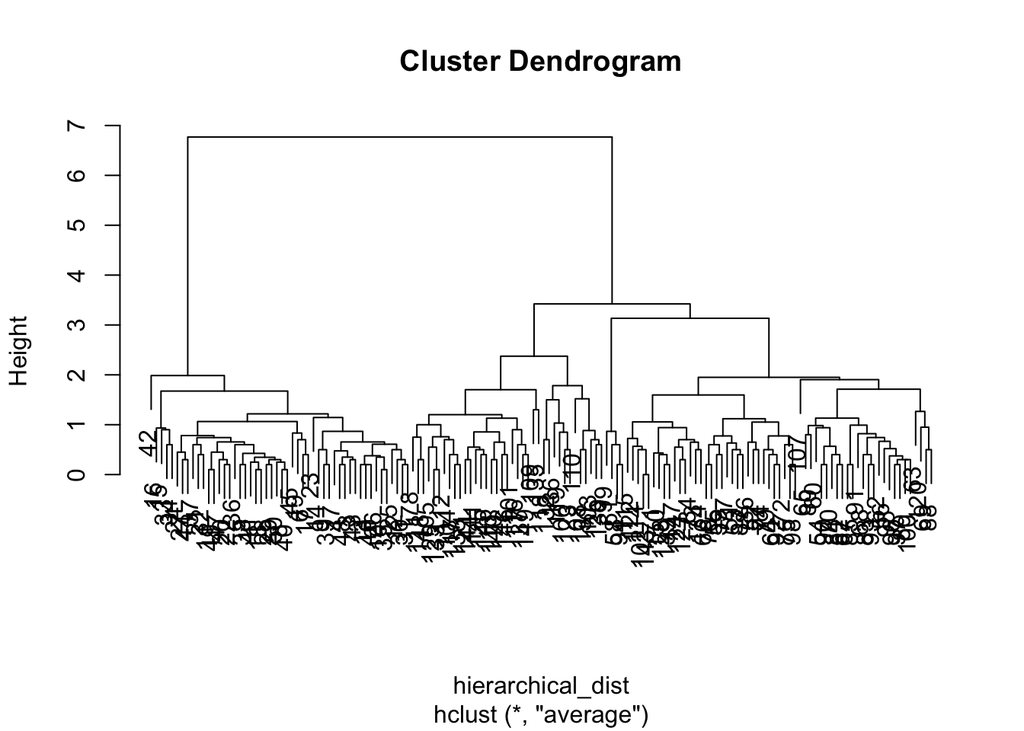

```r
#two different distance metrics
#manhattan
hierarchical_dist <- dist(subsetIris, method = "manhattan")
tree <- hclust(hierarchical_dist, method="average")
plot(tree)
```

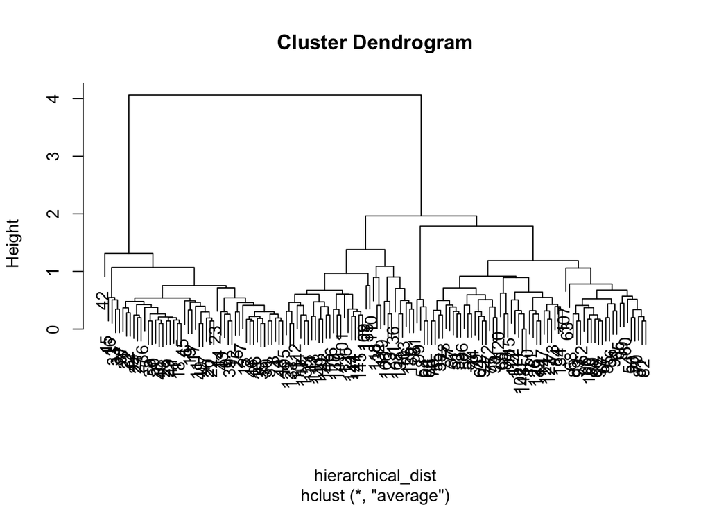

```r
#minkowski
hierarchical_dist <- dist(subsetIris, method = "minkowski")
tree <- hclust(hierarchical_dist, method="average")
plot(tree)
```

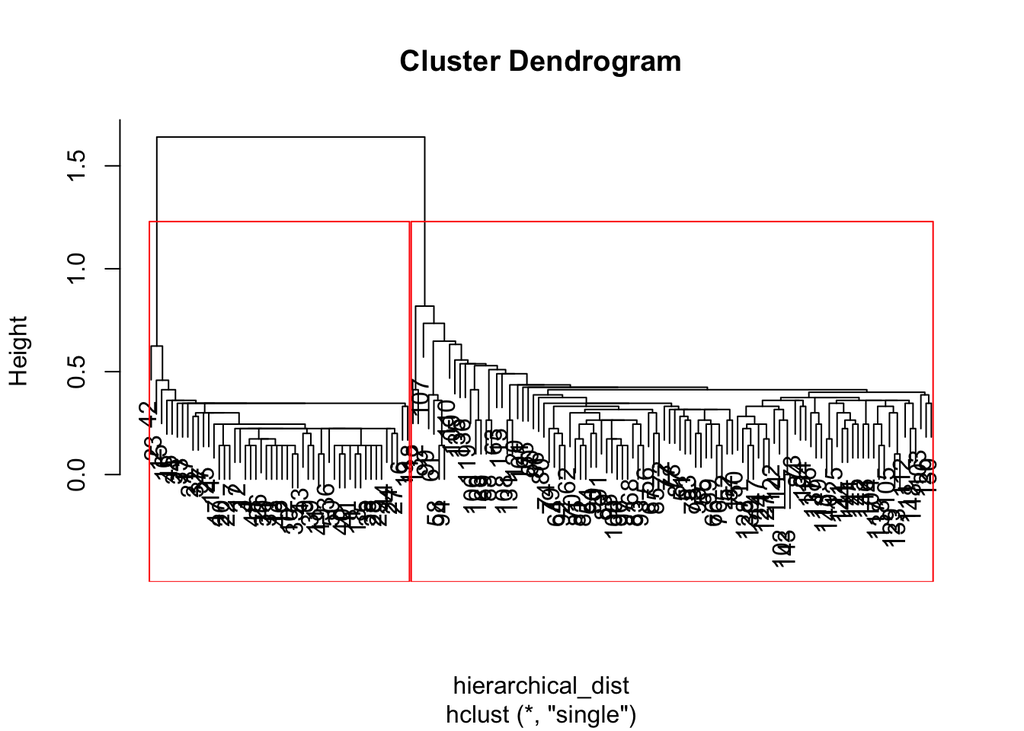

```r
#single
hierarchical_dist <- dist(subsetIris, method = "euclidean")
tree <- hclust(hierarchical_dist, method="single")
plot(tree)
tree_k1 <- cutree(tree, k = 2)
rect.hclust(tree, k = 2, h = NULL)
```

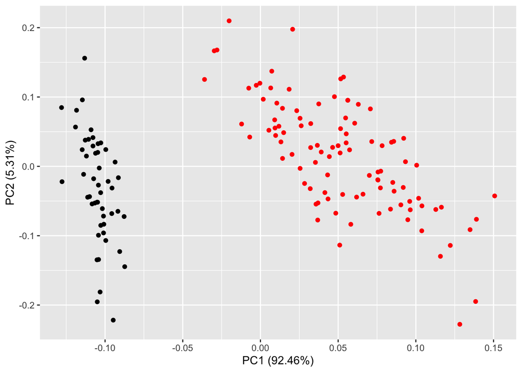

```r
firstCutTree <- cbind(subsetIris, tree_k1)
# firstCutTree
autoplot(prcomp(iris_pca), col=firstCutTree$tree_k1)
```

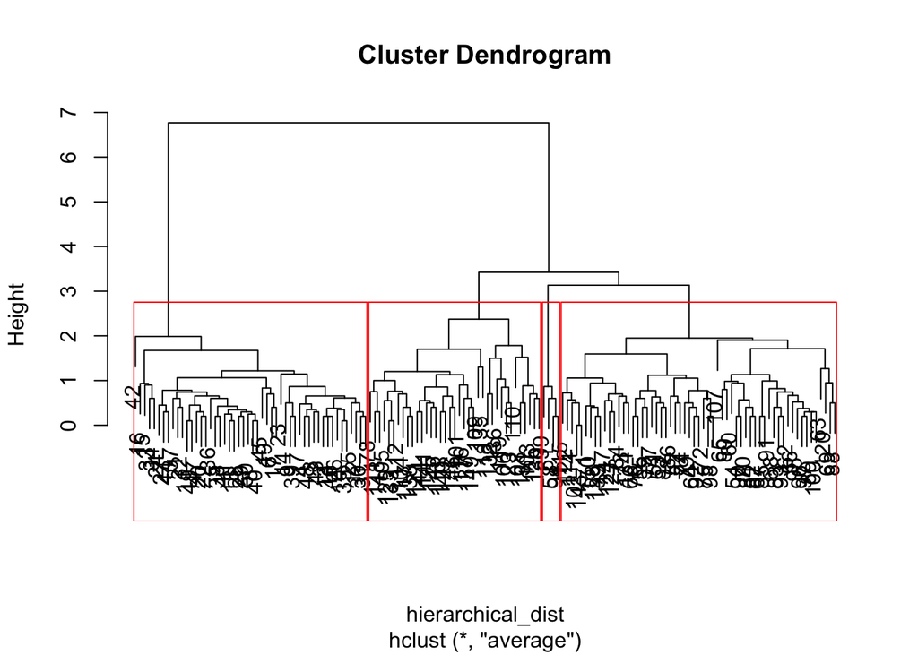

```r
#manhattan
hierarchical_dist <- dist(subsetIris, method = "manhattan")
tree <- hclust(hierarchical_dist, method="average")
plot(tree)
tree_k2 <- cutree(tree, k = 4)
rect.hclust(tree, k = 4, h = NULL)
```

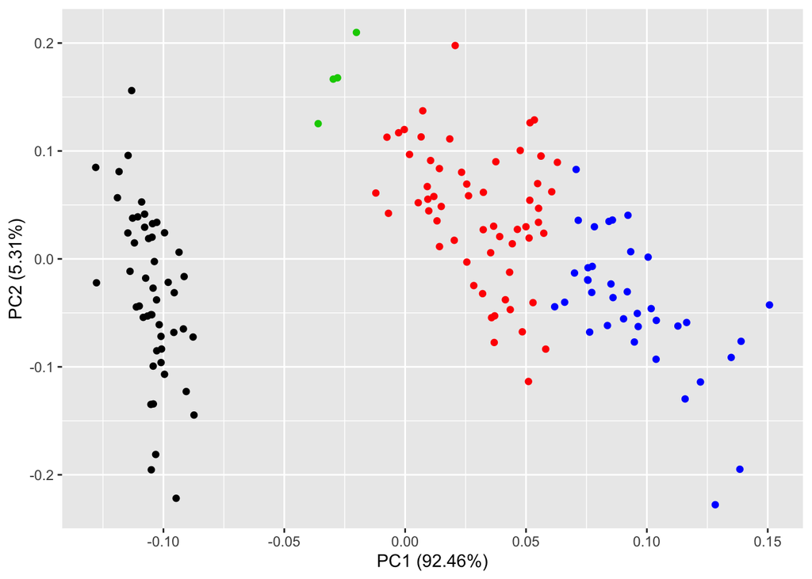

```r
# tree_k2
secondCutTree <- cbind(subsetIris, tree_k2)
# secondCutTree
autoplot(prcomp(iris_pca), col=secondCutTree$tree_k2)
```

# Optional material

On PCA:

Eigen Vectors and Eigen Values http://www.visiondummy.com/2014/03/eigenvalues-eigenvectors/ Linear Algebra by Prof. Gilbert Strang https://ocw.mit.edu/courses/mathematics/18-06-linear-algebra-spring-2010/video-lectures/ http://www.cs.otago.ac.nz/cosc453/student_tutorials/principal_components.pdf https://stats.stackexchange.com/questions/2691/making-sense-of-principal-component-analysis-eigenvectors-eigenvalues

On ICA:

Independent Component Analysis: Algorithms and Applications https://www.cs.helsinki.fi/u/ahyvarin/papers/NN00new.pdf Tutorial on ICA taken from http://rstudio-pubs-static.s3.amazonaws.com/93614_be30df613b2a4707b3e5a1a62f631d19.html

TA notes: -generally normalzied.